# **Practical Machine Learning Course Project**

#### *August 5, 2019*

### **Background**

Using devices such as Jawbone Up, Nike FuelBand, and Fitbit it is now possible to collect a large amount of data about personal activity relatively inexpensively. These type of devices are part of the quantified self movement - a group of enthusiasts who take measurements about themselves regularly to improve their health, to find patterns in their behavior, or because they are tech geeks. One thing that people regularly do is quantify how much of a particular activity they do, but they rarely quantify how well they do it. In this project, your goal will be to use data from accelerometers on the belt, forearm, arm, and dumbell of 6 participants. They were asked to perform barbell lifts correctly and incorrectly in 5 different ways. More information is available from the website here: http://web.archive.org/web/20161224072740/http:/groupware.les.inf.puc-rio.br/har (see the section on the Weight Lifting Exercise Dataset).

### **Data**

The training data for this project are available here:

https://d396qusza40orc.cloudfront.net/predmachlearn/pml-training.csv

The test data are available here:

https://d396qusza40orc.cloudfront.net/predmachlearn/pml-testing.csv

The data for this project come from this source: http://web.archive.org/web/20161224072740/http:/groupware.les.inf.puc-rio.br/har. If you use the document you create for this class for any purpose please cite them as they have been very generous in allowing their data to be used for this kind of assignment.

### **Loading the necessary packages**

```r
library(dplyr)
library(caret)
library(rpart)
library(rpart.plot)
library(RColorBrewer)
library(rattle)
library(randomForest)
library(corrplot)
library(gbm)
```

### **Downloading the Data from the Web**

```r
# Traning dataset
# Downloading the data from the web
if(!file.exists("./data")){dir.create("./data")}
training_fileUrl <- "https://d396qusza40orc.cloudfront.net/predmachlearn/pml-training.csv"
download.file(training_fileUrl, destfile = "./data/pml-training.csv")

# Testing dataset
# Downloading the data from the web
if(!file.exists("./data")){dir.create("./data")}
testing_fileUrl <- "https://d396qusza40orc.cloudfront.net/predmachlearn/pml-testing.csv"
download.file(testing_fileUrl, destfile = "./data/pml-testing.csv")
```

### **Loading the dataset**

```r
train <- read.csv("./data/pml-training.csv", header = TRUE,
                  na.strings = c("NA","",'#DIV/0!'))
test <- read.csv("./data/pml-testing.csv", header = TRUE,
                 na.strings = c("NA","",'#DIV/0!'))
```

### **Data Quality Score**

The quality of the data was checked, whether there are missing value for each column.

```r
# Data Quality Score Function
DataQualityScore <- function(raw_data) {

        df.QualityScore <- setNames(data.frame(matrix(ncol = 6, nrow = 0)), c("VARIABLE", "NULL", "INVALID",
                                                                              "TOTAL ERROR", "SAMPLE SIZE",
                                                                              "DATA QUALITY SCORE"))

        for (index in 1:ncol(raw_data)) {
                null <-  is.na(raw_data[,index])
                invalid <- !is.finite(raw_data[,index])

        for (i in 1:nrow(raw_data)) {
                if (null[i] == TRUE){
                        invalid[i] <- FALSE
                } else {
                        invalid[i] <- invalid[i]
                }
                }

        TotalNull <- sum(null)
        TotalInvalid <- sum(invalid)

        df.QualityScore[index,1] <- colnames(raw_data)[index]
        df.QualityScore[index,2] <- TotalNull
        df.QualityScore[index,3] <- TotalInvalid
        df.QualityScore[index,4] <- sum(TotalNull, TotalInvalid)
        df.QualityScore[index,5] <- nrow(raw_data)
        df.QualityScore[index,6] <- paste(100 - ((df.QualityScore[index,4]/df.QualityScore[index,5]) * 100),
                                          "%")
        }

        df.QualityScore
}
```

### **Data Cleaning**

Columns with missing values are removed. Columns 1 to 7 are also dropped as they are unnecessary for the data modeling.

```r
#Data Cleaning Function
DataCleaning <- function(x){
        Score <- DataQualityScore(x)
        scoreData <- data.frame(variable = Score[,'VARIABLE'],
                                score = as.numeric(substr(Score[,'DATA QUALITY SCORE'],
                                                          1, nchar(Score[,'DATA QUALITY SCORE'])-1)))
        scoreData[which(scoreData$score != 100),]
        #length(train[,as.character(scoreData[which(scoreData$score != 50),][[1]])])
        data_scored <- x[,as.character(scoreData[which(scoreData$score != 100),][[1]])]

        remainedCols <- names(x)[-which(names(x) %in% names(data_scored))]
        cleanedData = x[remainedCols]
        Score1 <- DataQualityScore(cleanedData)
        #returnDataset <- list(Score,Score1,data_scored,removedCols)
        return(cleanedData)
}

# Data Cleaning
train <- DataCleaning(train)
test <- DataCleaning(test)

# Removing unnecessary columns
train <- train[-c(1:7)]
test <- test[-c(1:7)]
```

### **Data Preprocessing**

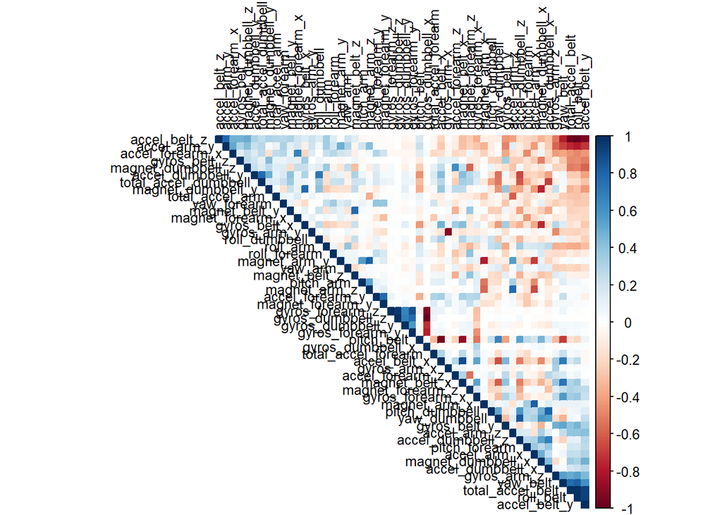

```r
# Data Splitting
set.seed(123)
inTrain <- createDataPartition(train$classe, p = 0.7, list = FALSE)
train <- train[inTrain, ]
validate <- train[-inTrain, ]

cor_mat <- cor(train[, -53])
corrplot(cor_mat, order = "FPC", method = "color", type = "upper",
         tl.cex = 0.8, tl.col = rgb(0, 0, 0))
```

```r
highlyCorrelated = findCorrelation(cor_mat, cutoff=0.7)

names(train)[highlyCorrelated]
```

```
##  [1] "accel_belt_z"      "roll_belt"         "accel_belt_y"
##  [4] "accel_arm_y"       "total_accel_belt"  "yaw_belt"
##  [7] "accel_dumbbell_z"  "accel_belt_x"      "pitch_belt"
## [10] "magnet_dumbbell_x" "accel_dumbbell_y"  "magnet_dumbbell_y"
## [13] "accel_dumbbell_x"  "accel_arm_x"       "accel_arm_z"
## [16] "magnet_arm_y"      "magnet_belt_z"     "accel_forearm_y"
## [19] "gyros_dumbbell_y"  "gyros_forearm_y"   "gyros_dumbbell_x"
## [22] "gyros_dumbbell_z"  "gyros_arm_x"
```

### **Model Building**

For this project we will use the following algorithms to predict the outcome.

1. Decision Tree
2. Random Forest
3. Gradient Boosting Classifier

#### **Decision Tree**

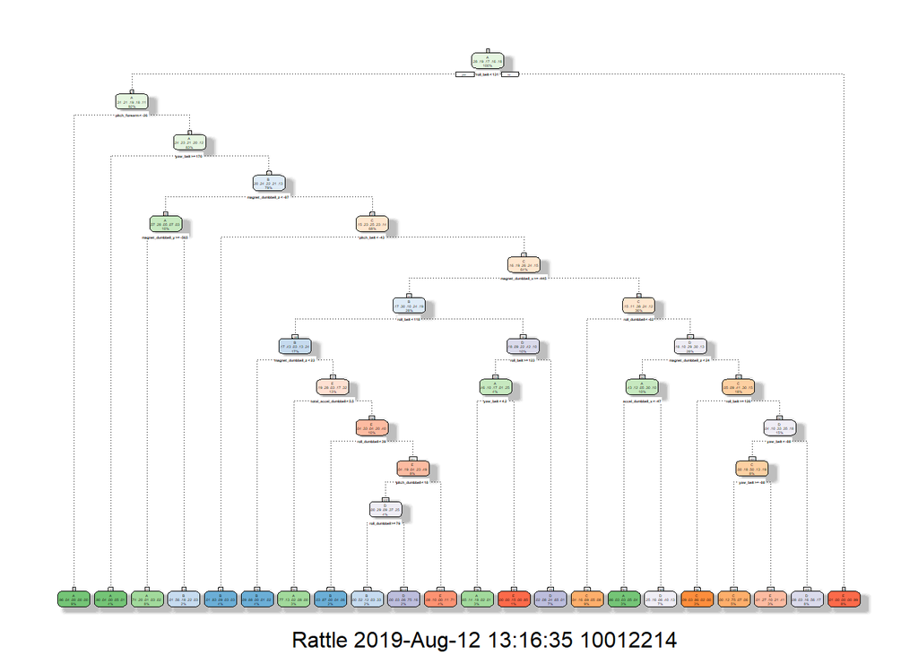

```r
set.seed(123)
model_decisiontree <- rpart(classe ~ ., data=train, method="class")
fancyRpartPlot(model_decisiontree)
```

```r
# Validate
predictTreeMod1 <- predict(model_decisiontree, validate, type = "class")
cmtree <- confusionMatrix(predictTreeMod1, validate$classe)
cmtree
```

```
## Confusion Matrix and Statistics
##
##           Reference
## Prediction   A   B   C   D   E
##          A 995 116  31  27  17
##          B  19 484  45  34  41
##          C  26  76 488  45  35
##          D 104  76 157 509 107
##          E  17  39  18  40 571
##
## Overall Statistics
##
##                Accuracy : 0.7401
##                  95% CI : (0.7264, 0.7534)
##     No Information Rate : 0.282
##     P-Value [Acc > NIR] : < 2.2e-16
##
##                   Kappa : 0.672
##
##  Mcnemar's Test P-Value : < 2.2e-16
##
## Statistics by Class:
##
##                      Class: A Class: B Class: C Class: D Class: E
## Sensitivity            0.8570   0.6119   0.6604   0.7771   0.7406
## Specificity            0.9354   0.9582   0.9461   0.8718   0.9659
## Pos Pred Value         0.8390   0.7769   0.7284   0.5341   0.8336
## Neg Pred Value         0.9434   0.9121   0.9272   0.9539   0.9417
## Prevalence             0.2820   0.1921   0.1795   0.1591   0.1873
## Detection Rate         0.2417   0.1176   0.1185   0.1236   0.1387
## Detection Prevalence   0.2881   0.1513   0.1627   0.2315   0.1664
## Balanced Accuracy      0.8962   0.7850   0.8032   0.8244   0.8533
```

#### **Random Forest**

```r
set.seed(123)
controlRF <- trainControl(method="cv", number=3, verboseIter=FALSE)
model_randomforest <- train(classe ~ ., data= train, method="rf", trControl=controlRF)
model_randomforest$finalModel
```

```
##
## Call:
##  randomForest(x = x, y = y, mtry = param$mtry)
##                Type of random forest: classification
##                      Number of trees: 500
## No. of variables tried at each split: 27
##
##         OOB estimate of  error rate: 0.68%
## Confusion matrix:
##      A    B    C    D    E class.error
## A 3901    3    0    0    2 0.001280082
## B   21 2629    7    1    0 0.010910459
## C    0   12 2380    4    0 0.006677796
## D    0    0   27 2222    3 0.013321492
## E    0    1    5    7 2512 0.005148515
```

```r
#Validate

pred_rfc <- predict(model_randomforest, newdata = validate)
cm_randomforest <- confusionMatrix(pred_rfc, validate$classe)
cm_randomforest
```

```
## Confusion Matrix and Statistics
##
##           Reference
## Prediction    A    B    C    D    E
##          A 1161    0    0    0    0
##          B    0  791    0    0    0
##          C    0    0  739    0    0
##          D    0    0    0  655    0
##          E    0    0    0    0  771
##
## Overall Statistics
##
##                Accuracy : 1
##                  95% CI : (0.9991, 1)
##     No Information Rate : 0.282
##     P-Value [Acc > NIR] : < 2.2e-16
##
##                   Kappa : 1
##
##  Mcnemar's Test P-Value : NA
##
## Statistics by Class:
##
##                      Class: A Class: B Class: C Class: D Class: E
## Sensitivity             1.000   1.0000   1.0000   1.0000   1.0000
## Specificity             1.000   1.0000   1.0000   1.0000   1.0000
## Pos Pred Value          1.000   1.0000   1.0000   1.0000   1.0000
## Neg Pred Value          1.000   1.0000   1.0000   1.0000   1.0000
## Prevalence              0.282   0.1921   0.1795   0.1591   0.1873
## Detection Rate          0.282   0.1921   0.1795   0.1591   0.1873
## Detection Prevalence    0.282   0.1921   0.1795   0.1591   0.1873
## Balanced Accuracy       1.000   1.0000   1.0000   1.0000   1.0000
```

#### **Gradient Boosting Classifier**

```r
set.seed(123)
controlGBM <- trainControl(method = "repeatedcv", number = 5, repeats = 1)
model_gbm  <- train(classe ~ ., data=train, method = "gbm", trControl = controlGBM, verbose = FALSE)
model_gbm$finalModel
```

```
## A gradient boosted model with multinomial loss function.
## 150 iterations were performed.
## There were 52 predictors of which 52 had non-zero influence.
```

```r
# print model summary
print(model_gbm)
```

```
## Stochastic Gradient Boosting
##
## 13737 samples
##    52 predictor
##     5 classes: 'A', 'B', 'C', 'D', 'E'
##
## No pre-processing
## Resampling: Cross-Validated (5 fold, repeated 1 times)
## Summary of sample sizes: 10989, 10989, 10991, 10988, 10991
## Resampling results across tuning parameters:
##
##   interaction.depth  n.trees  Accuracy   Kappa
##   1                   50      0.7498019  0.6829323
##   1                  100      0.8172086  0.7686278
##   1                  150      0.8520046  0.8127110
##   2                   50      0.8540442  0.8150895
##   2                  100      0.9055843  0.8805078
##   2                  150      0.9312082  0.9129337
##   3                   50      0.8969212  0.8694956
##   3                  100      0.9406713  0.9249289
##   3                  150      0.9606897  0.9502684
##
## Tuning parameter 'shrinkage' was held constant at a value of 0.1
##
## Tuning parameter 'n.minobsinnode' was held constant at a value of 10
## Accuracy was used to select the optimal model using the largest value.
## The final values used for the model were n.trees = 150,
##  interaction.depth = 3, shrinkage = 0.1 and n.minobsinnode = 10.
```

```r
#Validate

pred_gbm <- predict(model_gbm, newdata = validate)
cm_gbm <- confusionMatrix(pred_gbm, validate$classe)
cm_gbm
```

```
## Confusion Matrix and Statistics
##
##           Reference
## Prediction    A    B    C    D    E
##          A 1153   25    0    1    0
##          B    5  751   16    2    4
##          C    2   13  714   20    2
##          D    0    2    8  625    9
##          E    1    0    1    7  756
##
## Overall Statistics
##
##                Accuracy : 0.9713
##                  95% CI : (0.9658, 0.9762)
##     No Information Rate : 0.282
##     P-Value [Acc > NIR] : < 2.2e-16
##
##                   Kappa : 0.9637
##
##  Mcnemar's Test P-Value : 0.002275
##
## Statistics by Class:
##
##                      Class: A Class: B Class: C Class: D Class: E
## Sensitivity            0.9931   0.9494   0.9662   0.9542   0.9805
## Specificity            0.9912   0.9919   0.9890   0.9945   0.9973
## Pos Pred Value         0.9779   0.9653   0.9507   0.9705   0.9882
## Neg Pred Value         0.9973   0.9880   0.9926   0.9914   0.9955
## Prevalence             0.2820   0.1921   0.1795   0.1591   0.1873
## Detection Rate         0.2801   0.1824   0.1734   0.1518   0.1836
## Detection Prevalence   0.2864   0.1890   0.1824   0.1564   0.1858
## Balanced Accuracy      0.9922   0.9707   0.9776   0.9744   0.9889
```

```r
Results <- predict(model_gbm, newdata = test)
Results
```

```
##  [1] B A B A A E D B A A B C B A E E A B B B
## Levels: A B C D E
```